# Using K-Means Clustering to Determine Groupings of Fatal Car Crashes

Authors

Kyle Knuth

Siva Gopavarapu

Nikhitha Karlapudi

Eswar Sai Burugupalley

Bala Venkataprasad Sadhana Vittal

Published

April 11, 2024

Slides

## Introduction

### What is “K-Means Clustering”?

K-means clustering is a form of unsupervised learning which uses “K” clusters with assigned data to create groups. The main goal of K-means clustering is to classify data within clusters, which are as similar as possible, while also keeping it out of clusters as dissimilar as possible (Sinaga and Yang 2020). There are several methods of finding the optimal number of clusters, such as the Elbow method, Silhouette method, Gap statistic. The Silhouette method is used to visually find the number of clusters by using the silhouette coefficients. The silhouette coefficients can be between -1 and 1, where a value of 1 indicates the data is far from the neighboring cluster, a value of 0 means the data is close to the neighboring clusters and a value of -1 means the data was assigned to the wrong cluster (Shi et al. 2021). The Gap statistic finds the optimal number of clusters by comparing the within cluster dispersion changes to expected with a null dispersion (Tibshirani, Walther, and Hastie 2001). The Elbow method consists of plotting the sum of squared error versus “K” numbers and wherever the slope kinks at indicates the optimal number of clusters (Syakur et al. 2018).In addition to the standard preprocessing steps, the Canopy algorithm may also be utilized. The Canopy algorithm helps partion the data into smaller subsets in which k-means clustering is performed on each separate one to help reduce the computational complexity, and is best used for large and complex data sets and enhances the fault tolerance (Yuan and Yang 2019). When it comes to smaller and less complex data-sets, the other methods are better.

Once the amount of clusters has been determined, the quality of those clusters can be assessed. The Calinski-Harabasz criterion is used to determine the quality of the data and a higher value indicates the clusters are better separated (Qabbaah, Sammour, and Vanhoof 2019). The original data set is partitioned into clusters which have common traits and each cluster has a cluster center which starts from seed points. Then the K-means clustering method calculates the distance between each data point and each cluster center and takes an nxd matrix and assigns the data randomly to those clusters (Javadi et al. 2017). The data points are clustered by Euclidean distance of intensity values to the centroid, and a new centroid is then calculated and the previous steps are repeated until the labels of the clusters no longer change (Dubey et al. 2013). The Euclidean distance formula is used to compute the distance between the object center and each centroid(Fahlevi et al. 2020).

One of the most important parts to make K-means clustering more efficient is to find the most optimal centroids as quickly as possible. A solution to this is to use principal component analysis to estimate the initial centroids rather than random selection (Zubair et al. 2022). Basically this means, the process is looped over and over until there is a convergence and there are distinct clusters.

### Applications of K-Means Clustering

There have been many useful applications of K-means clustering ranging from color segmentation to identifying allergen severity by age group. There has been research done on using color segmentation with K-means clustering to identify the diseased parts of the fruit. This was achieved by transforming the image from RGB to L*a*b* and labeling the pixels of the image via K-means clustering (Dubey et al. 2013). Using this method, the diseased part of the fruit was picked out. K-means clustering can also be used to cluster geographic locations. Using an aquifer, K-means clustering was able to identify risk areas of the aquifer without using fixed weights (Javadi et al. 2017). When compared to data physically collected from the aquifer, it was shown the map produced from clustering was very accurate. Another example using geography is clustering regions of Indonesia, that was based on trade and accommodation facilities. Regions of Indonesia were clustered into three categories of high, medium, and low trade and accommodation (Munawar et al. 2021).

K-means clustering also has medical applications such as predicting chemotherapy response to cancer, how skin changes as you age, pregnancy problems, and how your allergen sensitivity changes as you age. Since it doesn’t have the same limitations as traditional methods, K-means clustering was chosen to predict chemotherapy response and was able to create clusters that acted as bio-markers to determine the treatment’s effectiveness (Nguyen et al. 2015). Based on different attributes of the pores in one’s skin, K-means clustering was able to create groups based on the detectability and size of the pore. From this information, as well as the mean age of each cluster, the changes in skin were able to be inferred by the age group of each cluster. Similarly, by using the data from immunoglobulin tests, K-means clustering created groups based on age to explain how allergen sensitivity actually decreased as age increased (Zhao et al. 2023). Pregnancy problems can also be analyzed with this method. K-means clustering was used to aid health professionals in making decisions about interventions to reduce pregnancy problems (Abbas et al. 2020).

K-means is also present in the tourism industry. By using a modified K-means algorithm, a tourist’s preferences and behaviors can be clustered, so the satisfaction and experience can be improved (Damos et al. 2024). Additionally, K-means is useful in agriculture. When using K-means clustering on soil, clusters were generated which improved the understanding of soil classification and spatial representation of the soil to make more informed decisions(Hot and Popović-Bugarin 2015).As a last example, our method was used to cluster counties together based on similarity to each other from economic factors to health behaviors, so county-level counterfactuals could be found (Strutz et al. 2022).

## Variations of K-Means Clustering

Apart from the traditional method of K-means clustering, there is also constrained K-means clustering. Constrained K-means clustering consists of having lower bounds for clusters and the distances between those clusters (Usami 2014). This method either deletes or consolidates clusters based off the constraints. Another variation of the traditional method is the improved K-means clustering algorithm. The improved algorithm uses two data structures to retain the cluster labels and their distances, while reducing the amount of repeated distance calculations (Na, Xumin, and Yong 2010). This improved algorithm improves speed and efficiency while maintaining accuracy. The next variation is called the filtering algorithm. The filtering algorithm is an optimized implementation of Lloyd’s K-means using a kd-tree structure, and performs best in clustering by refining candidate center selection through axis-aligned splitting hyperplanes and efficient trimming (Kanungo et al. 2002). The allure of this variation is it has great efficiency, is simplistic, and is scalable to higher dimensions. Genetic-based K-means (GBKM) clustering is another alternative offering speed and accuracy. What makes this algorithm different from the traditional one is the “centroids are encoded by chromosomes rather than random initial cluster centroids”(Chougule et al. 2015). GBKM also follows some of the same ideas of natural selection such as selection, crossover, and mutation. This modified K-means algorithm selects the fittest points from the clusters to produce a new generation by performing single point crossover and one-bit flip mutation, until the best results are found (Chougule et al. 2015). K-means clustering can also be used in conjunction with other tools. An example is the use of MapReduce from Hadoop to aid with the amount of data used. In this process, two files are created where one contains the centroid values and the other contains data point values and the mapper function is coded to calculate the distance between each centroid and data point, then assigned to the centroid with the lowest distance (Anchalia, Koundinya, and Srinath 2013). A new iteration of MapReduce will be performed again until the centroid value is not updated. Lastly, there is the extended K-means algorithm. Extended K-means takes the number of elements within a cluster into consideration by sorting the clusters in ascending order based on the number of elements in each cluster and either recruits or drops elements from the first cluster (Yi and Moon 2013). If there are n elements in the cluster, and an element is needed, the difference a-n, is calculated and points from other clusters are recruited.

## Limitations

Even though K-means clustering is a great tool for data analysis it still has its limitations. A few of those limitations are the random initializations of centroids, the requirement to know in advance the number of clusters present within a data-set, and also the inability of the algorithm to handle a wide variety of very different types of data (Ahmed, Seraj, and Islam 2020). If you were to choose too many or too few clusters, a lot of variability will be brought into the model. If the data were to become more complex, there would be issues in the clustering. There needs to be an adequate sample size and the data needs to be pre-processed very carefully due to its scalability.

## Methods

The methodology behind k-means clustering involves preprocessing the data, picking variables of interest, determining the optimal number of clusters, performing the k-means clustering, and identifying what each cluster consists of. The data is typically preprocessed by first removing any categorical variables, then removing outliers, and finally performing feature scaling. Once the data has been preprocessed, variables of interest will be picked and then the optimal number of clusters will be determined. The first method of determining how many clusters to use is the Silhouette Coefficient. The Silhouette Coefficient is used to measure how similar a data point is to its own cluster compared to other clusters based off a range of -1 to 1 where a more positive value means that the data is well placed within its cluster(Shi et al. 2021). The Silhouette Coefficient is shown below in equation 1:

$$S=b-a/max(b,\:a) \quad (1)$$

S: Silhouette coefficient

a: the average distance from one data point to the other within the same cluster

b: the minimum average distance from one point to points in other clusters

The next method of determining how many clusters to use is the Elbow method. The Elbow method consists of plotting the within-cluster sum of squares against the number of clusters and visually selecting a point where the rate of decrease significantly slows down (Shi et al. 2021). The Elbow method is shown below in equation 2:

$$WCSS=\sum^K_{k=1}\sum_{x_i=C_k}x_i-\mu^2_{k2} \quad (2)$$

WCSS: within-cluster sum of squares

x: data point in the cluster

C<sub>K</sub>: the current individual cluster

K: number of total clusters

$\mu_k$ : centroids corresponding to the cluster

The final method in determining how many clusters to use is the Gap statistic. This method finds the optimal number of clusters by comparing the within cluster dispersion changes to expected with a null dispersion(Tibshirani, Walther, and Hastie 2001). The Gap statistic is shown in equation 3:

$$Gap_n(k)=E^*_n\{log(W_K)\}-log(W_k) \quad (3)$$

Gap<sub>n</sub>(k): Gap statistic

E*n: expectation of sample size

n: sample size

k: number of clusters

W<sub>K</sub>:within-cluster sum of squares surrounding cluster means

The distance metric used for these methods is Euclidean distance. Euclidean distance is defined as the straight line distance between two points (Ultsch and Lötsch 2022). The Euclidean distance is shown in equation 4:

$$d(x,y)=\sqrt{\sum|x_i-y_i|^2} \quad (4)$$

d(x,y): Euclidean distance

x: x-coordinate point

y: y-coordinate point

The actual method of k-means clustering is an iterative process consisting of the following steps (Fahlevi et al. 2020):

- Determine the number of clusters
- Randomly select an initial centroid
- Using Euclidean distance, data is assigned to clusters in accordance to the distance of the centroids
- A new centroid is recalculated based on the mean of the previous centroids.
- All the previous steps are repeated until the mean of the centroids no longer changes

The assumptions of k-means clustering are as follows (Raykov et al. 2016):

- The data is in a sphere around the centroid and each sphere has the same radius
- The average of the points in a cluster is the centroid of the cluster meaning that outliers will dramatically affect clustering
- The density of each cluster is consistent
- The number of clusters is known and fixed

## Analysis and Results

### Data Description

For our fatal car crash clustering, we are using the dataset from “Fatalities” from the AER R package which originally came from US Department of Transportation Fatal Accident Reporting System and is dated from 1982-1988. In addition, the income variable was obtained from the US Bureau of Economic Analysis and unemployment rate was obtained from the US Bureau of Labor Statistics. The data includes all the states except Alaska and Hawaii.

| Variable | Variable Type | Description |
| --- | --- | --- |
| state | Categorical | A categorical variable that represents the state |
| year | Categorical | The year is indicated by the categorical factor |
| spirits | Continuous | A numerical value indicating the amount of spirits consumed. |
| unemp | Continuous | The unemployment rate expressed as a numerical value. |
| income | Continuous | A numerical value in dollars that represents the per capita personal income. |
| emppop | Continuous | The employment to population ratio expressed as a numerical value. |
| beertax | Continuous | The tax on a case of beer expressed as a numerical value. |
| baptist | Continuous | A number that indicates the proportion of Southern Baptists in the general population. |
| mormon | Continuous | A numerical value that indicates the proportion of Mormons in the general population. |
| drinkage | Continuous | A number that represents the minimum age at which alcohol is permitted. |
| dry | Continuous | A numerical number that indicates the proportion of people living in “dry” counties. |
| youngdrivers | Continuous | A numerical value indicating the proportion of drivers between the ages of 15 and 24. |
| miles | Continuous | A numerical value indicating the average number of miles driven by each driver. |
| breath | Boolean | A categorical factor that denotes the existence of a law requiring a preliminary breath test. |
| jail | Boolean | A categorical factor that indicates whether a jail sentence is required. |
| service | Boolean | A categorical factor that denotes the existence of a community service requirement. |
| fatal | Continuous | A number that indicates the overall number of people killed in cars. |
| nfatal | Continuous | A numerical value that indicates the quantity of car deaths that occur at night. |
| sfatal | Continuous | A numerical value that indicates how many people have died in just one vehicle. |
| fatal1517 | Continuous | A numerical value that indicates how many teenagers between the ages of 15 and 17 were killed in cars. |
| nfatal1517 | Continuous | A numerical value that indicates how many teenagers, aged 15 to 17, are killed in cars at night. |
| fatal1820 | Continuous | A numerical value that indicates the total number of 18–20-year-olds who die in cars. |
| nfatal1820 | Continuous | A numerical value that indicates how many teenagers, aged 18 to 20, are killed in cars at night. |
| fatal2124 | Continuous | A numerical value that indicates how many people aged 21 to 24 are killed in cars. |
| nfatal2124 | Continuous | A numerical value that indicates how many people aged 21 to 24 are killed in cars. |
| afatal | Continuous | A numerical value that indicates the quantity of drunk driving deaths. |
| pop | Continuous | A numerical figure that indicates the entire population. |
| pop1517 | Continuous | A numerical value that indicates the population of people aged 15 to 17. |
| pop1820 | Continuous | A numerical value that denotes the 18–20 year old population. |
| pop2124 | Continuous | A numerical value that denotes the population of people aged 21 to 24. |
| milestot | Continuous | A number (in millions) that indicates the total number of miles driven by a vehicle. |
| unemppopus | Continuous | The US unemployment rate expressed as a numerical value. |
| Emppopus | Continuous | The US employment to population ratio expressed as a numerical value. |
| gsp | Continuous | A numerical value that indicates the Gross State Product’s (GSP) rate of change. |

# Data analysis (Preprocessing and cleaning)

Install necessary packages to perform data cleaning, analysis, visualization, and model building.

```r
library(maps)
library(mapproj)
library(psych)
library(caret)
library(AER)
library(e1071)
library(missForest)
library(MASS)
library(fpc)
library(cluster)
library(factoextra)
library(tidyverse)
library(waterfalls)
library(corrplot)
library(ggcorrplot)
library(googlesheets4)
data("Fatalities")
df1=Fatalities
df=Fatalities
df3=Fatalities
```

```r
head(df)
```

```
  state year spirits unemp   income   emppop  beertax baptist  mormon drinkage
1    al 1982    1.37  14.4 10544.15 50.69204 1.539379 30.3557 0.32829    19.00
2    al 1983    1.36  13.7 10732.80 52.14703 1.788991 30.3336 0.34341    19.00
3    al 1984    1.32  11.1 11108.79 54.16809 1.714286 30.3115 0.35924    19.00
4    al 1985    1.28   8.9 11332.63 55.27114 1.652542 30.2895 0.37579    19.67
5    al 1986    1.23   9.8 11661.51 56.51450 1.609907 30.2674 0.39311    21.00
6    al 1987    1.18   7.8 11944.00 57.50988 1.560000 30.2453 0.41123    21.00
      dry youngdrivers    miles breath jail service fatal nfatal sfatal
1 25.0063     0.211572 7233.887     no   no      no   839    146     99
2 22.9942     0.210768 7836.348     no   no      no   930    154     98
3 24.0426     0.211484 8262.990     no   no      no   932    165     94
4 23.6339     0.211140 8726.917     no   no      no   882    146     98
5 23.4647     0.213400 8952.854     no   no      no  1081    172    119
6 23.7924     0.215527 9166.302     no   no      no  1110    181    114
  fatal1517 nfatal1517 fatal1820 nfatal1820 fatal2124 nfatal2124  afatal
1        53          9        99         34       120         32 309.438
2        71          8       108         26       124         35 341.834
3        49          7       103         25       118         34 304.872
4        66          9       100         23       114         45 276.742
5        82         10       120         23       119         29 360.716
6        94         11       127         31       138         30 368.421
      pop  pop1517  pop1820  pop2124 milestot unempus emppopus         gsp
1 3942002 208999.6 221553.4 290000.1    28516     9.7     57.8 -0.02212476
2 3960008 202000.1 219125.5 290000.2    31032     9.6     57.9  0.04655825
3 3988992 197000.0 216724.1 288000.2    32961     7.5     59.5  0.06279784
4 4021008 194999.7 214349.0 284000.3    35091     7.2     60.1  0.02748997
5 4049994 203999.9 212000.0 263000.3    36259     7.0     60.7  0.03214295
6 4082999 204999.8 208998.5 258999.8    37426     6.2     61.5  0.04897637
```

We plan to conduct our analysis on a chosen dataset as shown below. We convert the percentage of Baptists and Mormons to a count as well as pick our variables of interest such as spirits consumption, the amount of Baptists, the amount of Mormons, the amount the alcohol is taxed, and alcohol related car crashes. These variables were chosen to observe the relationship between alcohol consumption and religion in regards to fatal car crashes.

```r
df$baptist=df$baptist/100
df$mormon=df$mormon/100
df$baptist=df$baptist*df$pop
df$mormon=df$mormon*df$pop
df=df[c(3,7,8,9,26)]
describe(df)
```

```
        vars   n      mean        sd   median   trimmed      mad    min
spirits    1 336      1.75      0.68     1.67      1.67     0.53   0.79
beertax    2 336      0.51      0.48     0.35      0.42     0.24   0.04
baptist    3 336 353164.70 557450.81 58039.21 239427.34 84461.06   0.00
mormon     4 336  60798.39 160724.27 17809.97  24459.64 17199.78 930.33
afatal     5 336    293.33    303.58   211.59    234.89   200.14  24.60
               max      range skew kurtosis       se
spirits       4.90       4.11 2.20     6.63     0.04
beertax       2.72       2.68 2.17     5.14     0.03
baptist 2879464.51 2879464.51 2.26     6.24 30411.44
mormon  1049096.92 1048166.59 5.04    26.72  8768.23
afatal     2094.90    2070.30 2.70     9.28    16.56
```

We also check to see if there are any missing or null values in our data and there does not appear to be any.

```r
print(c(sum(is.na(df)),sum(is.null(df))))
```

```
[1] 0 0
```

The five graphs below show a boxplot of each variable of interest. As seen below there are some outliers that need to be removed so we can cluster our data effectively.

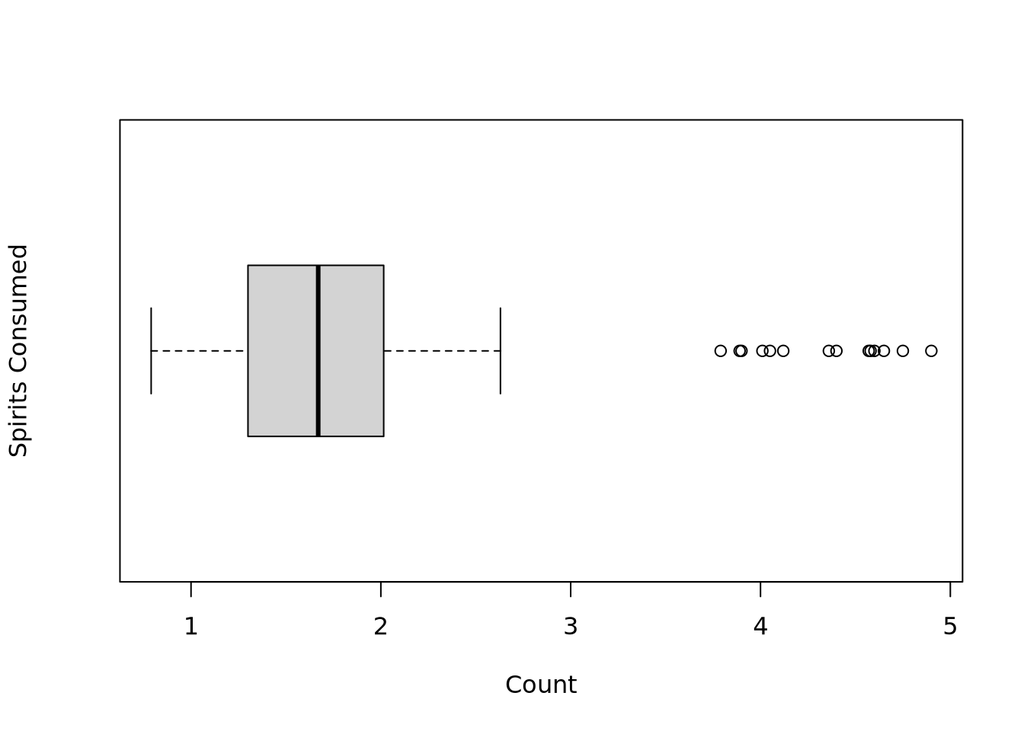

```r
boxplot(df$spirits, horizontal = TRUE, xlab="Count", ylab="Spirits Consumed")
```

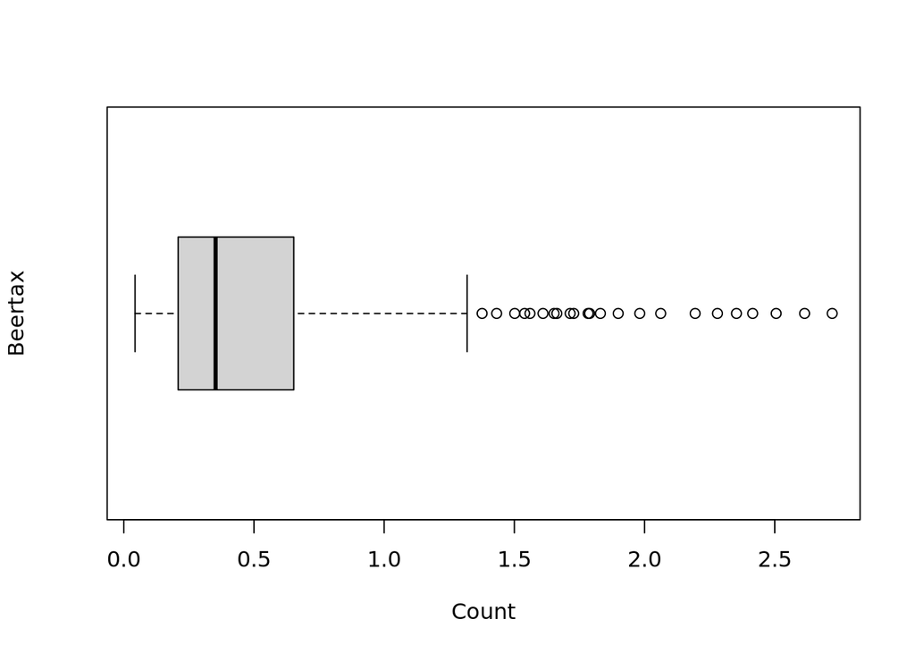

```r
boxplot(df$beertax, horizontal = TRUE, xlab="Count", ylab="Beertax")
```

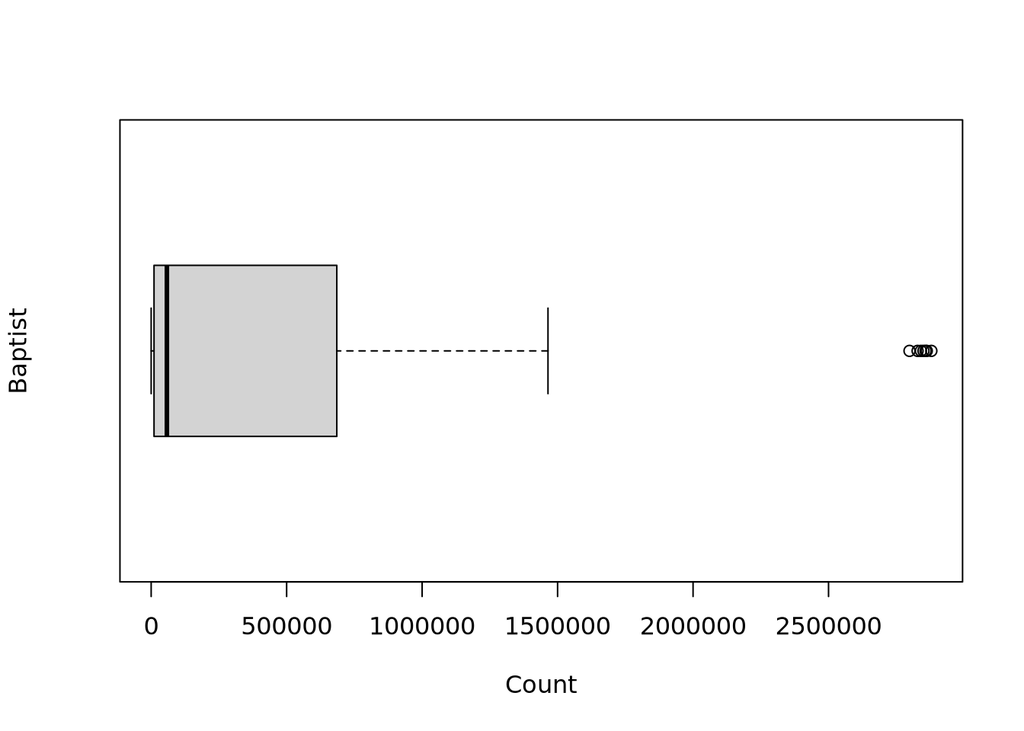

```r
boxplot(df$baptist, horizontal = TRUE, xlab="Count", ylab="Baptist")
```

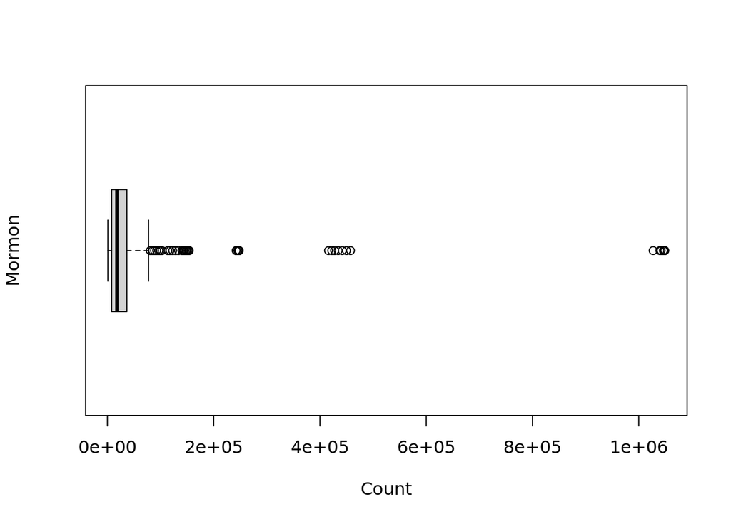

```r
boxplot(df$mormon, horizontal = TRUE, xlab="Count", ylab="Mormon")
```

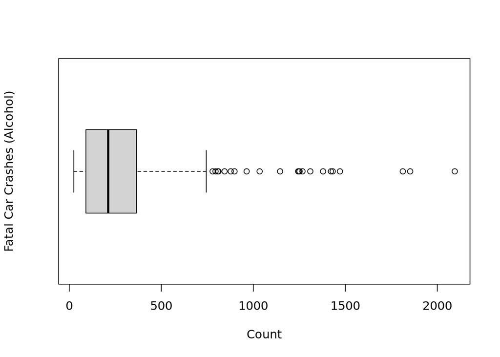

```r
boxplot(df$afatal, horizontal = TRUE, xlab="Count", ylab="Fatal Car Crashes (Alcohol)")
```

Next, we first check if there are any outliers in our data and remove them before scaling the data. We need to remove the outliers since it can affect the centroid in the k-means clsutering process. In addition, the data needs to be scaled since k-means clustering is reliant on Euclidean distance and a large difference in values can adversly affect it.

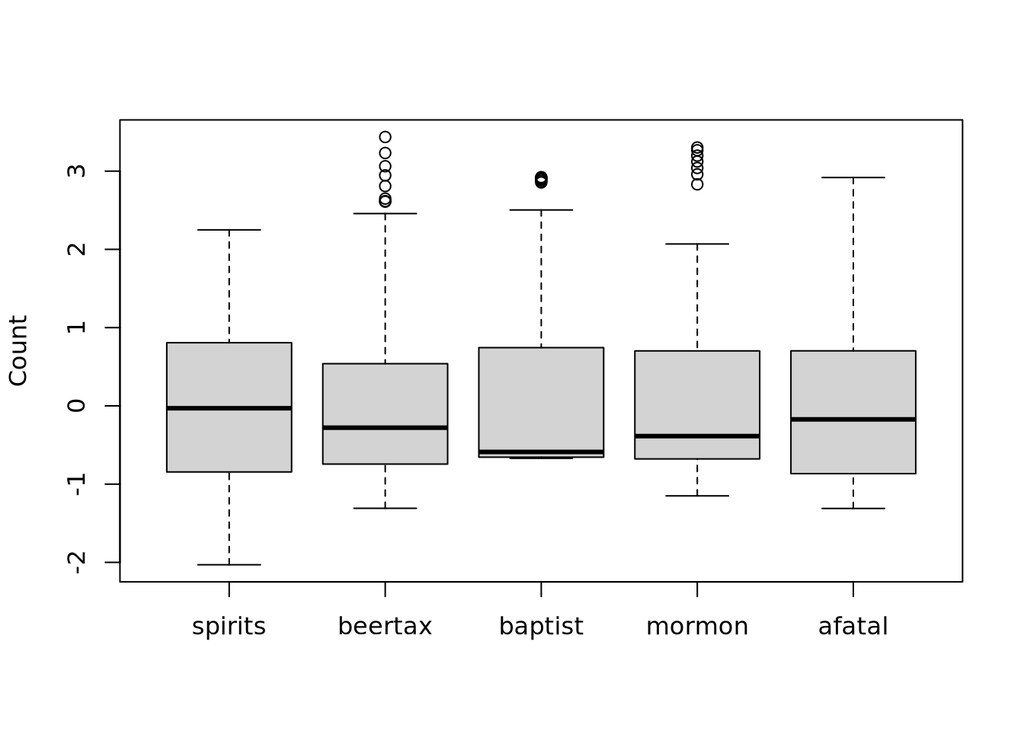

```r
detection=function(x) {
  q1=quantile(x,probs=.25)
  q3=quantile(x,probs=.75)
  iqr=q3-q1
  x>q3+(iqr*1.5)|x<q1-(iqr*1.5)}

elimination= function(df,cols=names(df)) {
  for(col in cols) {
    df=df[!detection(df[[col]]),]}
  return(df)}
column_names=c('spirits','baptist','mormon', 'beertax', 'afatal')
df2=df
cleaned_df_2=elimination(df2,column_names)
cleaned_df2=as.data.frame(scale(cleaned_df_2))
boxplot(cleaned_df2, ylab="Count")
```

### Identifying the optimal number of clusters

The next step in our analysis is to figure how many clusters to use. The elbow method is performed and as shown by the graph, the optimal number of clusters is 6.

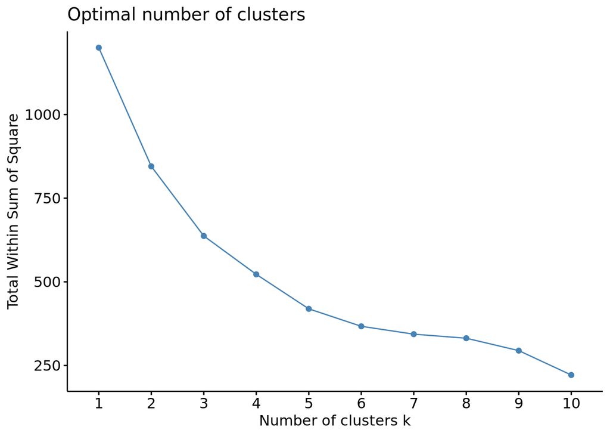

```r
fviz_nbclust(cleaned_df2, kmeans, method = "wss")
```

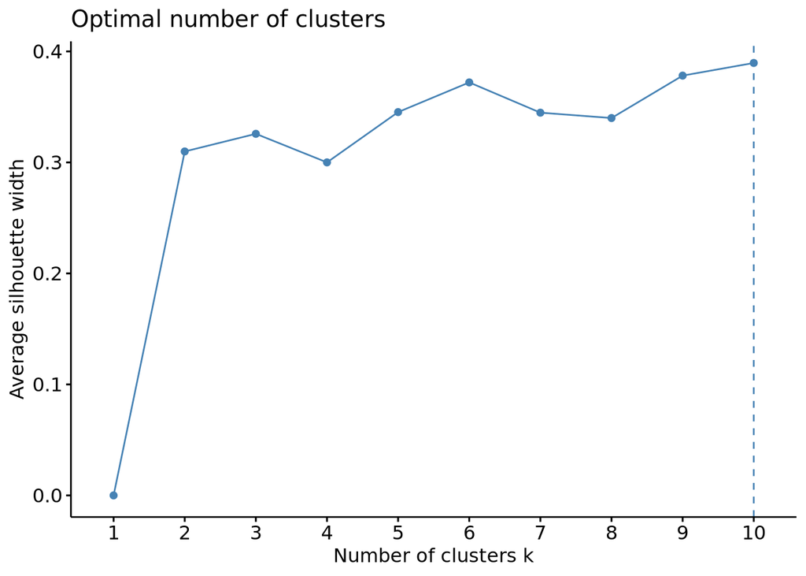

```r
fviz_nbclust(cleaned_df2, kmeans, method = "silhouette")
```

Lastly we are using the gap statistic as a final check to determine the best number of clusters. This graph also shows 6 clusters as being the most optimal.

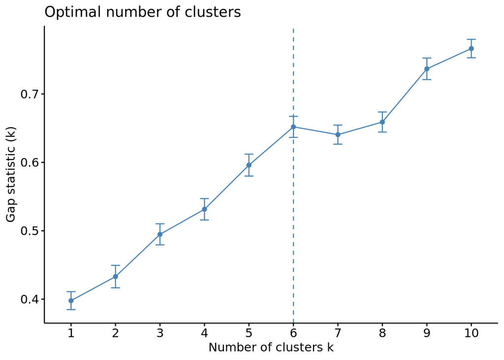

```r
fviz_nbclust(cleaned_df2, kmeans, method = "gap_stat")
```

### Modeling With K-Means Clustering

Now we are using our selected number of clusters (6) for our dataframe to perform k-means clustering. The plot below shows clustering for our dataframe consisting of our variables of interest.

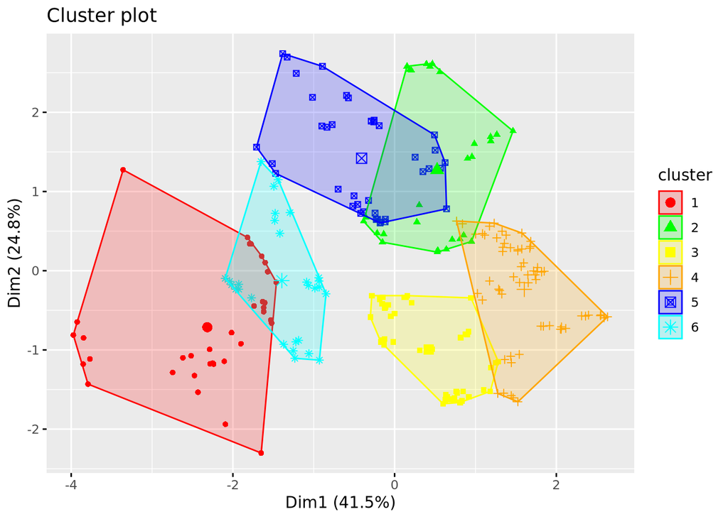

```r
custom_colors=c("red","green", "yellow", "orange", "blue", "cyan")
km <- kmeans(cleaned_df2, centers= 6, nstart = 25)
fviz_cluster(km,data=cleaned_df2, geom = "point")+scale_color_manual(values = custom_colors)+scale_fill_manual(values = custom_colors)
```

Using between sum of squares divided by the total sum of squares as a metric of best fit for our clusters, our first k-means clustering analysis shows 71.4%

```r
km
```

```
K-means clustering with 6 clusters of sizes 35, 28, 48, 63, 39, 28

Cluster means:
     spirits    beertax    baptist     mormon     afatal
1 -0.4561039  1.8490488  1.5952980  0.3918395  0.5843325
2  0.1368614 -0.6174539 -0.5166243  1.7164714 -0.7229940
3 -0.6348741  0.3213418 -0.6119006 -0.7336699 -0.7497544
4  1.2041473 -0.5892843 -0.6206896 -0.7171974 -0.5667082
5 -0.1493950 -0.5030219 -0.4061842  0.5782229  1.5395044
6 -0.9796214 -0.2182016  1.5337823 -0.1402387  0.4086553

Clustering vector:
 15  16  17  18  19  20  21  29  30  31  32  33  34  35  36  37  38  39  40  41
  6   6   6   6   6   6   6   2   2   2   2   2   2   2   4   4   4   4   4   4
 42  43  44  45  46  47  48  49  53  71  72  73  74  75  76  77  78  79  80  81
```

[output cut: 32 more lines]

# Results

After performing k-means clustering a summary table is created to show the average characteristics of each cluster

```r
cleaned_df_2$cluster=km$cluster
clustertable=cleaned_df_2%>%
  group_by(cluster) %>%
  summarise_all("mean")
print(clustertable)
```

```
# A tibble: 6 × 6
  cluster spirits beertax baptist mormon afatal
    <int>   <dbl>   <dbl>   <dbl>  <dbl>  <dbl>
1       1    1.47   0.930 865674. 22263.   323.
2       2    1.72   0.237  58579. 40587.   117.
3       3    1.39   0.501  22168.  6693.   113.
4       4    2.18   0.245  18809.  6921.   142.
5       5    1.60   0.270 100785. 24841.   473.
6       6    1.24   0.350 842165. 14902.   295.
```

```r
cleaned_df2$cluster=km$cluster
clustertable2=cleaned_df2%>%
  group_by(cluster) %>%
  summarise_all("mean")
print(clustertable2)
```

```
# A tibble: 6 × 6
  cluster spirits beertax baptist mormon afatal
    <int>   <dbl>   <dbl>   <dbl>  <dbl>  <dbl>
1       1  -0.456   1.85    1.60   0.392  0.584
2       2   0.137  -0.617  -0.517  1.72  -0.723
3       3  -0.635   0.321  -0.612 -0.734 -0.750
4       4   1.20   -0.589  -0.621 -0.717 -0.567
5       5  -0.149  -0.503  -0.406  0.578  1.54
6       6  -0.980  -0.218   1.53  -0.140  0.409
```

### Cluster analysis (average)

The standardized data will be used to make fair comparisons regarding the religion variables

Cluster 1:

- consists of average of 1.47 alcoholic drinks consumed per person
- There was an average of 323 alcohol related car crashes
- The average beertax was 93 cents
- This cluster consisted of mainly Baptists rather than Mormons

Cluster 2:

- Consists of an average of 1.72 alcoholic drinks consumed per person
- There was an average of 117 alcohol related car crashes
- The average beertax was 23.7 cents
- This cluster consists of somewhat more Mormons than Baptists

Cluster 3:

- Consists of an average of 1.39 alcoholic drinks consumed per person
- There was an average of 113 alcohol related car crashes
- The average beertax was 50.1 cents
- This cluster consists had similar amounts of Baptists and Mormons

Cluster 4:

- Consists of an average of 2.18 alcoholic drinks consumed per person
- There was an average of 142 alcohol related car crashes
- The average beertax was 24.5 cents
- This cluster consists had similar amounts of Baptists and Mormons

Cluster 5:

- Consists of an average of 1.6 alcoholic drinks consumed per person
- There was an average of 473 alcohol related car crashes
- The average beertax was 27 cents
- This cluster contains more Mormons than Baptists

Cluster 6:

- Consists of an average of 1.24 alcoholic drinks consumed per person
- There was an average of 295 alcohol related car crashes
- The average beertax was 35 cents
- This cluster contains significantly more Baptists than Mormons

### Cluster analysis (by variable)

In this first chart it is shown that cluster 5 had the highest number of car crash fatalities related to alcohol while clusters 2 and 3 had the lowest amount. Cluster 1 had the second highest amount.

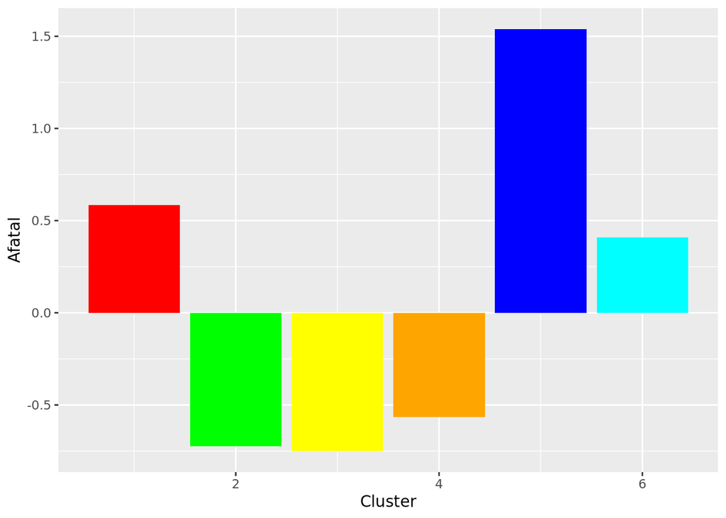

```r
y=clustertable2$cluster
x=clustertable2$afatal
data=as.data.frame(x)
data$y=y

ggplot(data, aes(x = y, y = x)) +
  geom_bar(stat = "identity", fill = custom_colors) +
  labs(x = "Cluster", y = "Afatal")
```

In this next chart, cluster 4 had the highest number of alcohol consumed while cluster 6 had the lowest amount. The second highest was cluster 2.

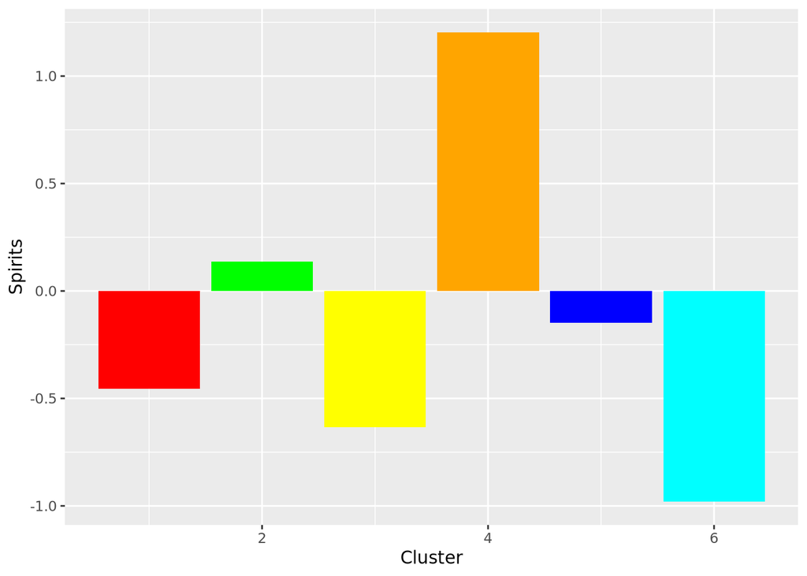

```r
y=clustertable2$cluster
x=clustertable2$spirits
data=as.data.frame(x)
data$y=y

ggplot(data, aes(x = y, y = x)) +
  geom_bar(stat = "identity", fill = custom_colors) +
  labs(x = "Cluster", y = "Spirits")
```

As shown below, clusters 1 and 6 had the highest population of Baptists while clusters 3 and 4 had the lowest amount.

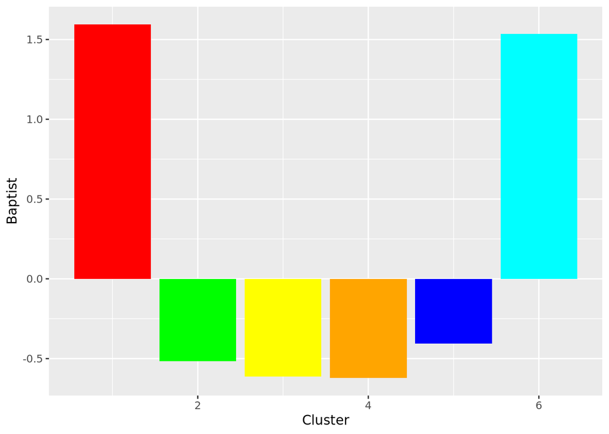

```r
y=clustertable2$cluster
x=clustertable2$baptist
data=as.data.frame(x)
data$y=y

ggplot(data, aes(x = y, y = x)) +
  geom_bar(stat = "identity", fill = custom_colors) +
  labs(x = "Cluster", y = "Baptist")
```

In this chart, cluster 2 had the highest population of Mormons and clusters 3 and 4 had the lowest population.

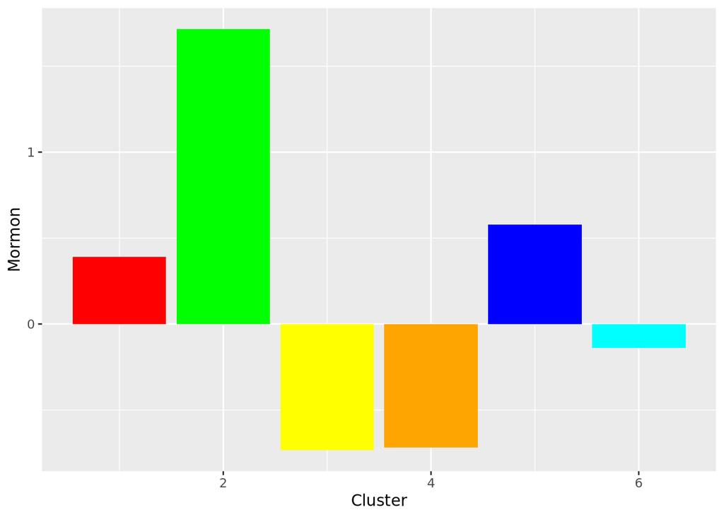

```r
y=clustertable2$cluster
x=clustertable2$mormon
data=as.data.frame(x)
data$y=y

ggplot(data, aes(x = y, y = x)) +
  geom_bar(stat = "identity", fill = custom_colors) +
  labs(x = "Cluster", y = "Mormon")
```

Cluster 1 had the highest beertax while clusters 2 and 4 had the lowest beertax.

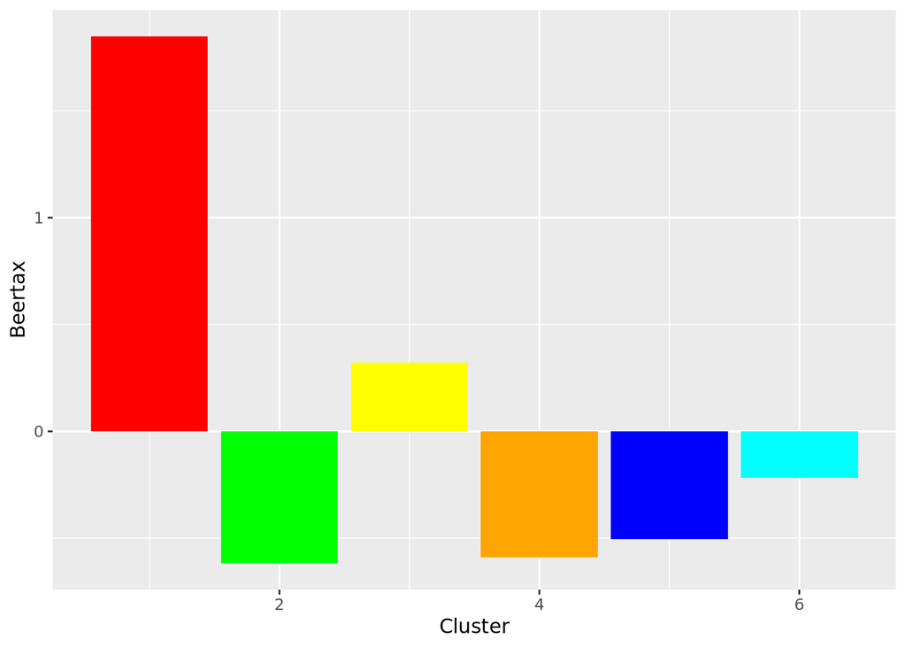

```r
y=clustertable2$cluster
x=clustertable2$beertax
data=as.data.frame(x)
data$y=y

ggplot(data, aes(x = y, y = x)) +
  geom_bar(stat = "identity", fill = custom_colors) +
  labs(x = "Cluster", y = "Beertax")
```

### Cluster Analysis (State)

The below graphs show the same information as the bar charts but at the state level. We created a subset of the original data that now has the clusters from our k-means clustering analyis to make inferences. This is to highlight which states belong to which cluster.

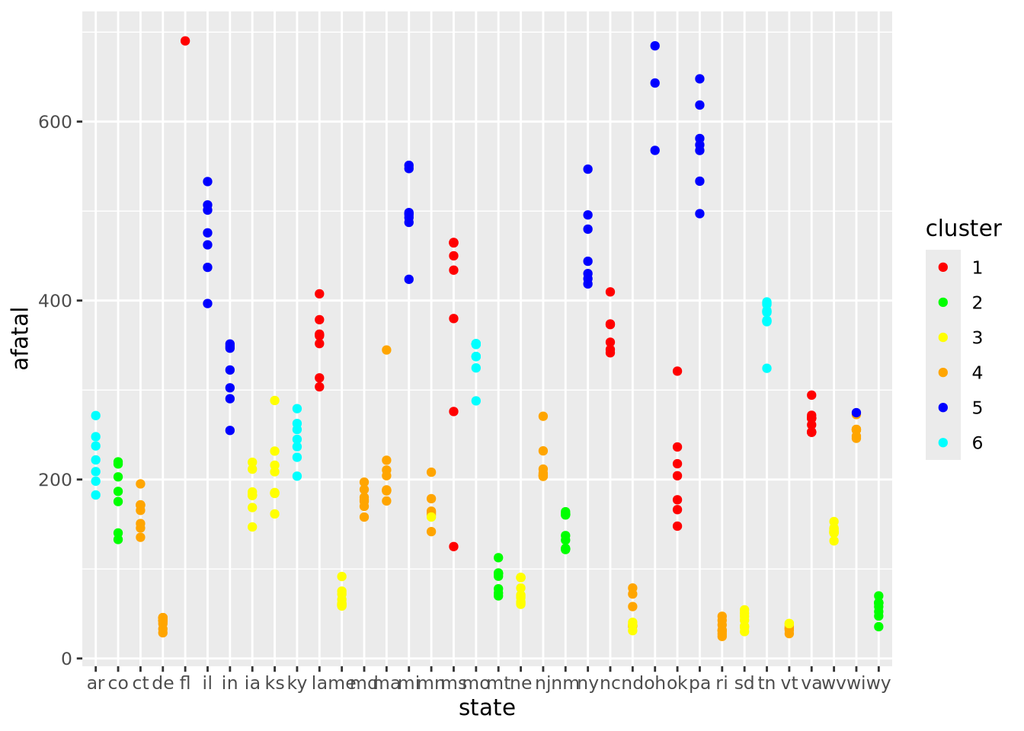

```r
dfsub=Fatalities
subsetdf=dfsub[rownames(dfsub) %in% rownames(cleaned_df_2),]
subsetdf$cluster=km$cluster
subsetdf$cluster=as.factor(subsetdf$cluster)
custom_colors=c("red", "green", "yellow", "orange", "blue", "cyan", "purple")
ggplot(subsetdf, aes(x=state, afatal, color=cluster)) + geom_point()+ scale_color_manual(values = custom_colors)
```

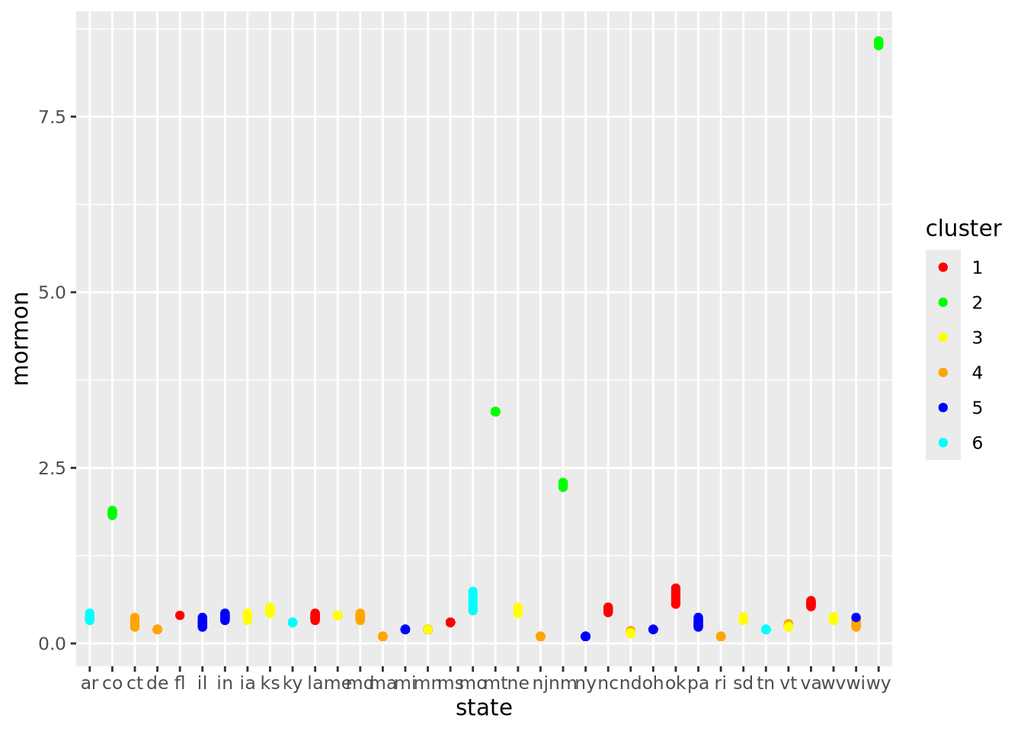

```r
ggplot(subsetdf, aes(x=state, mormon, color=cluster)) + geom_point()+ scale_color_manual(values = custom_colors)
```

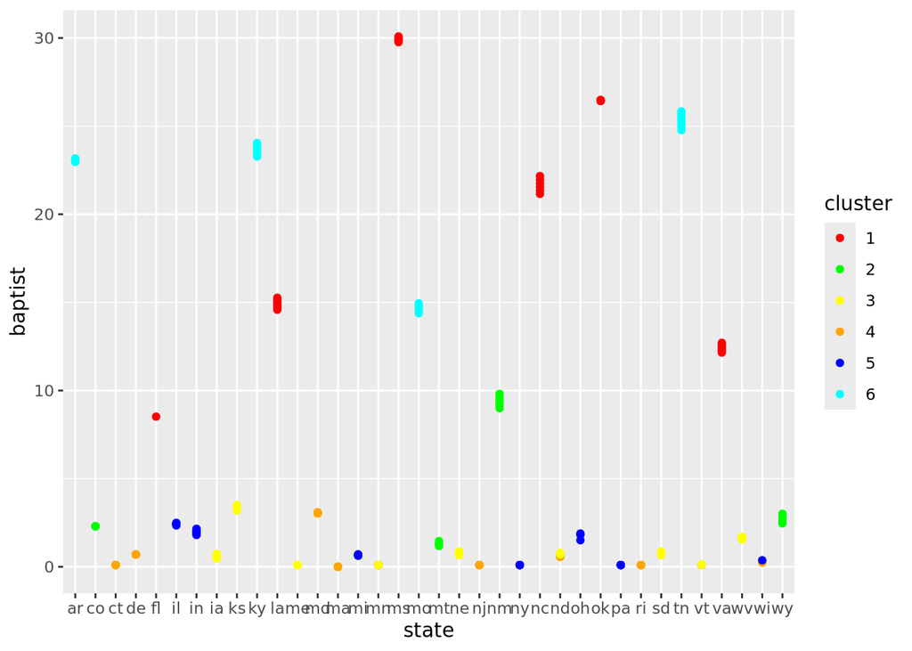

```r
ggplot(subsetdf, aes(x=state, baptist, color=cluster)) + geom_point()+ scale_color_manual(values = custom_colors)
```

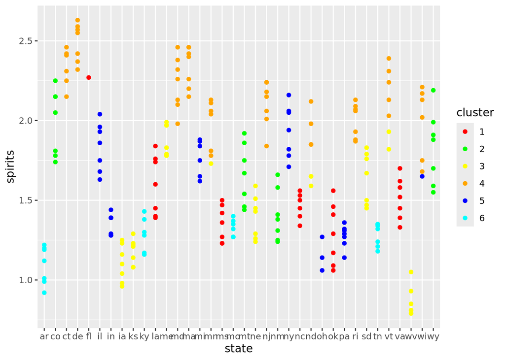

```r
ggplot(subsetdf, aes(x=state, spirits, color=cluster)) + geom_point()+ scale_color_manual(values = custom_colors)
```

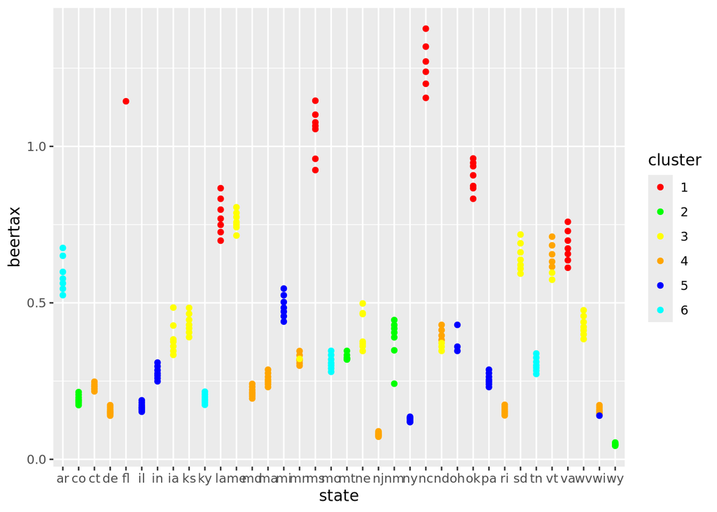

```r
ggplot(subsetdf, aes(x=state, beertax, color=cluster)) + geom_point()+ scale_color_manual(values = custom_colors)
```

The map below shows a better depiction of the clustered states:

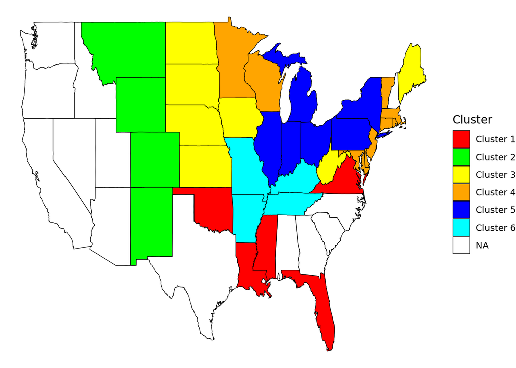

```r
map_data=map_data("state")

state_colors=c("florida"="red",
               "louisiana"="red",
               "mississippi"="red",
               "north Carolina"="red",
               "oklahoma"="red",
               "virginia"="red",
               "arkansas"="cyan",
               "kentucky"="cyan",
               "missouri"="cyan",
               "tennessee"="cyan",
               "colorado"="green",
               "montana"="green",
               "new mexico"="green",
               "wyoming"="green",
               "connecticut"="orange",
               "delaware"="orange",
               "maryland"="orange",
               "massachusetts"="orange",
               "minnesota"="orange",
               "new jersey"="orange",
               "north dakota"="yellow",
               "rhode island"="orange",
               "vermont"="orange",
               "wisconsin"="orange",
               "illinois"="blue",
               "indiana"="blue",
               "michigan"="blue",
               "new york"="blue",
               "ohio"="blue",
               "pennsylvania"="blue",
               "iowa"="yellow",
               "kansas"="yellow",
               "maine"="yellow",
               "nebraska"="yellow",
               "south dakota"="yellow",
               "west virginia"="yellow")



map_data$color=ifelse(map_data$region %in%
                        names(state_colors),
                      state_colors[map_data$region], NA)

map_data$Cluster=ifelse(map_data$color=="red", "Cluster 1",
                        ifelse(map_data$color=="green","Cluster 2",
                               ifelse(map_data$color=="yellow", "Cluster 3",
                                      ifelse(map_data$color=="orange","Cluster 4",
                                             ifelse(map_data$color=="blue", "Cluster 5",
                                                    ifelse(map_data$color=="cyan","Cluster 6",NA))))))


custom_colors=c("Cluster 1"="red", "Cluster 2"="green", "Cluster 3"="yellow", "Cluster 4"="orange", "Cluster 5"="blue", "Cluster 6"="cyan")


ggplot(map_data,aes(x=long,y=lat,group=group, fill=Cluster))+geom_polygon(color="black", size=0.25)+theme_void()+scale_fill_manual(values = custom_colors, na.value="white")
```

As shown by the map, the clustered states seem form 6 different sub-regions of the U.S. based off our chosen variables. Cluster 1 appears to contain the South. Cluster 2 seems to be the West. Cluster 3 is in the center of the U.S. with two states residing further East. Cluster 4 is primarily in the Northeast of the U.S. Cluster 5 is in the Great Lakes and MidEast area. Lastly, Cluster 6 is in the Eastern-Central part of the U.S.

### Conclusion

In conclusion, we have analyzed data from the “Fatalities” dataset, which contains information on fatal car crashes from the US Department of Transportation’s Fatal Accident Reporting System. As shown by our analysis, K-means clustering is a great option to group data together to generate useful insights. We have shown how the analysis was performed such as pre-processing the data, determining the optimal number of clusters as well as creating and implementing our K-means clustering model. We generated 6 clusters to explain trends regarding alcohol related car crashes related to alcohol consumption, religion, and beer tax. From this analysis, we were able to assign these clusters to the rest of the data and create subregions of the United States, each with its own characteristics, and make inferences. These inferences can help provide an understanding of how each region handles alcohol and its impacts. Using k-means clustering, we were able to obtain important insights into the complex interactions between these variables, which could possible help identify possible areas for focused intervention.

In addition, we recognize that choosing the correct number clusters can be difficult as well as very subjective. Due to this, there can be varying results and accuracy. For example, interpreting our graphs of the Elbow method and Silhouette method was somewhat subjective, but the decision became easier after observing the Gap Statistic.

## References

Abbas, Syed Ali, Adil Aslam, Aqeel Ur Rehman, Wajid Arshad Abbasi, Saeed Arif, and Syed Zaki Hassan Kazmi. 2020. “K-Means and k-Medoids: Cluster Analysis on Birth Data Collected in City Muzaffarabad, Kashmir.” *IEEE Access* 8: 151847–55. https://doi.org/10.1109/ACCESS.2020.3014021.

Ahmed, Mohiuddin, Raihan Seraj, and Syed Mohammed Shamsul Islam. 2020. “The k-Means Algorithm: A Comprehensive Survey and Performance Evaluation.” *Electronics* 9 (8). https://doi.org/10.3390/electronics9081295.

Anchalia, Prajesh P, Anjan K Koundinya, and NK Srinath. 2013. “MapReduce Design of k-Means Clustering Algorithm.” In *2013 International Conference on Information Science and Applications (ICISA)*, 1–5. IEEE.

Chougule, Pooja, AD Thakare, Prajakta Kale, Madhura Gole, and Priyanka Nanekar. 2015. “Genetic k-Means Algorithm for Credit Card Fraud Detection.” *International Journal of Computer Science and Information Technologies (IJCSIT)* 6 (2): 1724–27.

Damos, Mohamed A., Jun Zhu, Weilian Li, Elhadi Khalifa, Abubakr Hassan, Rashad Elhabob, Alaa Hm, and Esra Ei. 2024. “Enhancing the k-Means Algorithm Through a Genetic Algorithm Based on Survey and Social Media Tourism Objectives for Tourism Path Recommendations.” *ISPRS International Journal of Geo-Information* 13 (2). https://doi.org/10.3390/ijgi13020040.

Dubey, Shiv Ram, Pushkar Dixit, Nishant Singh, and Jay Prakash Gupta. 2013. “Infected Fruit Part Detection Using k-Means Clustering Segmentation Technique.”

Fahlevi, Muhammad Reza, Dini Ridha Dwiki Putri, Fetty Ade Putri, Maulia Rahman, Lahmudin Sipahutar, and Muhatri Muhatri. 2020. “Determination of Rice Quality Using the k-Means Clustering Method.” In *2020 2nd International Conference on Cybernetics and Intelligent System (ICORIS)*, 1–6. https://doi.org/10.1109/ICORIS50180.2020.9320839.

Hot, Elma, and Vesna Popović-Bugarin. 2015. “Soil Data Clustering by Using k-Means and Fuzzy k-Means Algorithm.” In *2015 23rd Telecommunications Forum Telfor (TELFOR)*, 890–93. https://doi.org/10.1109/TELFOR.2015.7377608.

Javadi, S, SM Hashemy, K Mohammadi, KWF Howard, and A Neshat. 2017. “Classification of Aquifer Vulnerability Using k-Means Cluster Analysis.” *Journal of Hydrology* 549: 27–37.

Kanungo, Tapas, David M Mount, Nathan S Netanyahu, Christine D Piatko, Ruth Silverman, and Angela Y Wu. 2002. “An Efficient k-Means Clustering Algorithm: Analysis and Implementation.” *IEEE Transactions on Pattern Analysis and Machine Intelligence* 24 (7): 881–92.

Munawar, Aang, Gen Gen Gendalasari, I Made Gede Ariestova Kurniawan, D Purnomo, Nur Haris Ependi, Muhammad Isa Indrawan, Muhammad Sadri, et al. 2021. “Cluster Application with k-Means Algorithm on the Population of Trade and Accommodation Facilities in Indonesia.” In *Journal of Physics: Conference Series*, 1933:012027. 1. IOP Publishing.

Na, Shi, Liu Xumin, and Guan Yong. 2010. “Research on k-Means Clustering Algorithm: An Improved k-Means Clustering Algorithm.” In *2010 Third International Symposium on Intelligent Information Technology and Security Informatics*, 63–67. Ieee.

Nguyen, Huyen T, Guang Jia, Zarine K Shah, Kamal Pohar, Amir Mortazavi, Debra L Zynger, Lai Wei, Xiangyu Yang, Daniel Clark, and Michael V Knopp. 2015. “Prediction of Chemotherapeutic Response in Bladder Cancer Using k-Means Clustering of Dynamic Contrast-Enhanced (DCE)-MRI Pharmacokinetic Parameters.” *Journal of Magnetic Resonance Imaging* 41 (5): 1374–82.

Qabbaah, Hamzah, George Sammour, and Koen Vanhoof. 2019. “Using k-Means Clustering and Data Visualization for Monetizing Logistics Data.” In *2019 2nd International Conference on New Trends in Computing Sciences (ICTCS)*, 1–6. IEEE.

Raykov, Yordan P, Alexis Boukouvalas, Fahd Baig, and Max A Little. 2016. “What to Do When k-Means Clustering Fails: A Simple yet Principled Alternative Algorithm.” *PloS One* 11 (9): e0162259.

Shi, Congming, Bingtao Wei, Shoulin Wei, Wen Wang, Hai Liu, and Jialei Liu. 2021. “A Quantitative Discriminant Method of Elbow Point for the Optimal Number of Clusters in Clustering Algorithm.” *Eurasip Journal on Wireless Communications and Networking* 2021: 1–16.

Sinaga, Kristina P, and Miin-Shen Yang. 2020. “Unsupervised k-Means Clustering Algorithm.” *IEEE Access* 8: 80716–27.

Strutz, Kelly L, Zhehui Luo, Jennifer E Raffo, Cristian I Meghea, Peggy Vander Meulen, and Lee Anne Roman. 2022. “Determining County-Level Counterfactuals for Evaluation of Population Health Interventions: A Novel Application of k-Means Cluster Analysis.” *Public Health Reports* 137 (5): 849–59.

Syakur, MA, B Khusnul Khotimah, EMS Rochman, and Budi Dwi Satoto. 2018. “Integration k-Means Clustering Method and Elbow Method for Identification of the Best Customer Profile Cluster.” In *IOP Conference Series: Materials Science and Engineering*, 336:012017. IOP Publishing.

Tibshirani, Robert, Guenther Walther, and Trevor Hastie. 2001. “Estimating the Number of Clusters in a Data Set via the Gap Statistic.” *Journal of the Royal Statistical Society: Series B (Statistical Methodology)* 63 (2): 411–23.

Ultsch, Alfred, and Jörn Lötsch. 2022. “Euclidean Distance-Optimized Data Transformation for Cluster Analysis in Biomedical Data (EDOtrans).” *BMC Bioinformatics* 23 (1): 233.

Usami, Satoshi. 2014. “Constrained k-Means on Cluster Proportion and Distances Among Clusters for Longitudinal Data Analysis.” *Japanese Psychological Research* 56 (4): 361–72.

Yi, Faliu, and Inkyu Moon. 2013. “Extended k-Means Algorithm.” In *2013 5th International Conference on Intelligent Human-Machine Systems and Cybernetics*, 2:263–66. https://doi.org/10.1109/IHMSC.2013.210.

Yuan, Chunhui, and Haitao Yang. 2019. “Research on k-Value Selection Method of k-Means Clustering Algorithm.” *J* 2 (2): 226–35.

Zhao, Lei, Jie Fang, Yong Ji, Yingying Zhang, Xin Zhou, Junfeng Yin, Min Zhang, and Wuping Bao. 2023. “K-Means Cluster Analysis of Characteristic Patterns of Allergen in Different Ages: Real Life Study.” *Clinical and Translational Allergy* 13 (7): e12281.

Zubair, Md, MD Asif Iqbal, Avijeet Shil, MJM Chowdhury, Mohammad Ali Moni, and Iqbal H Sarker. 2022. “An Improved k-Means Clustering Algorithm Towards an Efficient Data-Driven Modeling.” *Annals of Data Science*, 1–20.